# Melbourne Housing Price Prediction

Author

Lasya Harini Banka

## Introduction

For this project, I worked with Melbourne housing data to predict house prices based on features such as the number of rooms, property type, distance and location. I used two models a regression tree and a random forest, to see which one gave better predictions. I then used the better performing model to build a prediction API..

## Data Preparation

The original dataset had 34857 rows and 21 columns. I selected seven predictors and used Price as the response variable. I removed rows with missing prices and converted categorical variables into factors. The cleaned dataset had 27247 rows.

```r
# Load packages
library(tidyverse)

# Read the original data
housing <- read_csv("data/Melbourne_housing_FULL.csv")

# Keep variables for modeling
# Remove rows with missing prices
housing_model <- housing %>%
  select(Price, Rooms, Type, Distance,
         Bathroom, Car, Landsize, Regionname) %>%
  filter(!is.na(Price)) %>%
  mutate(
    Type = as.factor(Type),
    Regionname = as.factor(Regionname)
  )

# Check the cleaned data
dim(housing_model)
```

```
[1] 27247     8
```

```r
summary(housing_model)
```

```
     Price              Rooms        Type         Distance        Bathroom
 Min.   :   85000   Min.   : 1.000   h:18472   Min.   : 0.00   Min.   :0.000
 1st Qu.:  635000   1st Qu.: 2.000   t: 2866   1st Qu.: 6.40   1st Qu.:1.000
 Median :  870000   Median : 3.000   u: 5909   Median :10.50   Median :1.000
 Mean   : 1050173   Mean   : 2.992             Mean   :11.28   Mean   :1.592
 3rd Qu.: 1295000   3rd Qu.: 4.000             3rd Qu.:14.00   3rd Qu.:2.000
 Max.   :11200000   Max.   :16.000             Max.   :48.10   Max.   :9.000
                                               NA's   :1       NA's   :6447
      Car            Landsize                             Regionname
 Min.   : 0.000   Min.   :     0.0   Southern Metropolitan     :8524
 1st Qu.: 1.000   1st Qu.:   219.0   Northern Metropolitan     :7864
 Median : 2.000   Median :   512.0   Western Metropolitan      :5815
 Mean   : 1.715   Mean   :   593.5   Eastern Metropolitan      :3272
 3rd Qu.: 2.000   3rd Qu.:   664.0   South-Eastern Metropolitan:1341
 Max.   :18.000   Max.   :433014.0   Eastern Victoria          : 166
 NA's   :6824     NA's   :9265       (Other)                   : 265
```

## Exploratory Data Analysis

I used a histogram, boxplot and scatterplot to explore housing prices and see how they relate to property type and number of rooms.

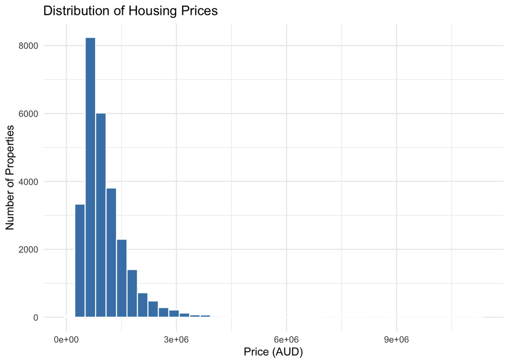

```r
# Check the distribution of prices
ggplot(housing_model, aes(x = Price)) +
  geom_histogram(bins = 40, fill = "steelblue", color = "white") +
  labs(
    title = "Distribution of Housing Prices",
    x = "Price (AUD)",
    y = "Number of Properties"
  ) +
  theme_minimal()
```

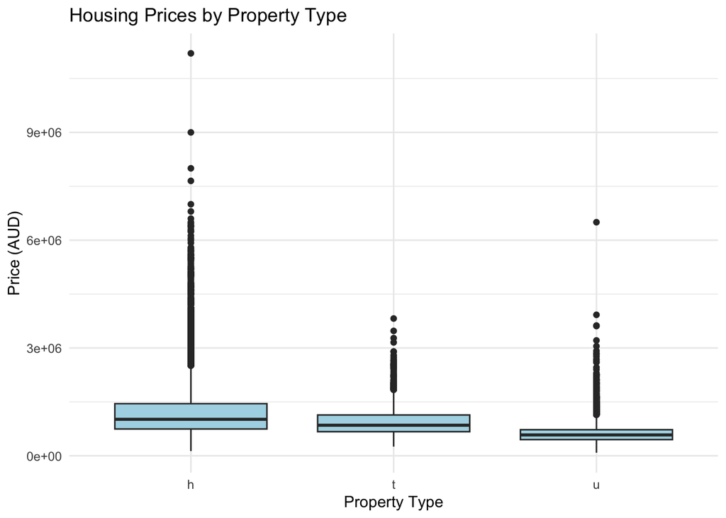

```r
# Compare prices by property type
ggplot(housing_model, aes(x = Type, y = Price)) +
  geom_boxplot(fill = "lightblue") +
  labs(
    title = "Housing Prices by Property Type",
    x = "Property Type",
    y = "Price (AUD)"
  ) +
  theme_minimal()
```

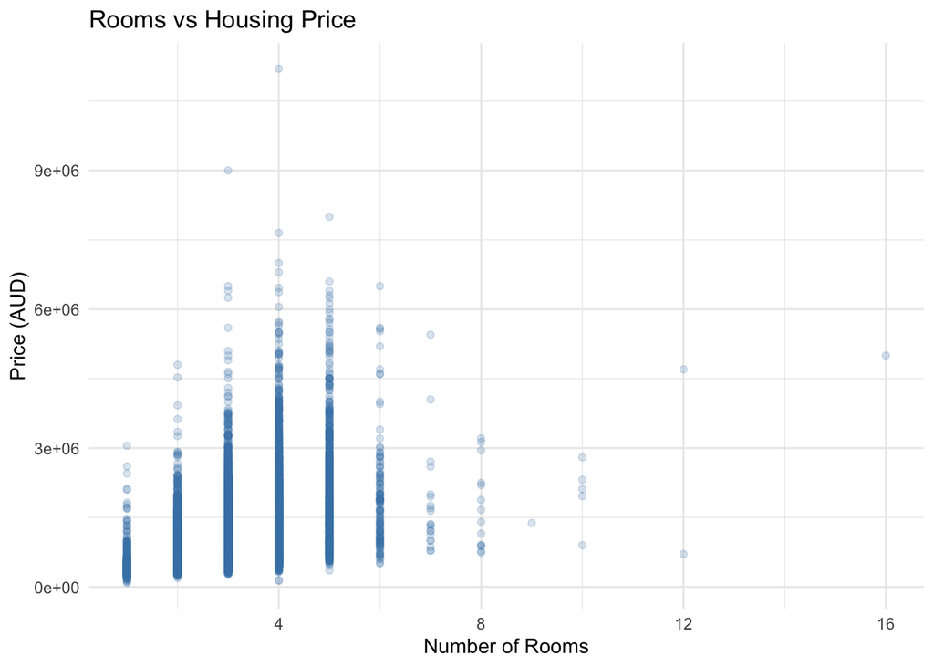

```r
# Check rooms and price
ggplot(housing_model, aes(x = Rooms, y = Price)) +
  geom_point(alpha = 0.2, color = "steelblue") +
  labs(
    title = "Rooms vs Housing Price",
    x = "Number of Rooms",
    y = "Price (AUD)"
  ) +
  theme_minimal()
```

The plots gave me a better understanding of how housing prices differ across properties. I also checked for missing values and found that some numeric variables had quite a few missing observations so I handled those during preprocessing.

```r
# Check missing values
housing_model %>%
  summarise(across(everything(), ~sum(is.na(.))))
```

```
# A tibble: 1 × 8
  Price Rooms  Type Distance Bathroom   Car Landsize Regionname
  <int> <int> <int>    <int>    <int> <int>    <int>      <int>
1     0     0     0        1     6447  6824     9265          0
```

## Model Training

I split the data into 70% training and 30% testing. I used 5-fold cross-validation to tune the models and median imputation to handle missing numeric values.

```r
# Load modeling packages
library(tidymodels)

# Split the data
set.seed(123)
housing_split <- initial_split(housing_model, prop = 0.70)

train_data <- training(housing_split)
test_data <- testing(housing_split)

# Check the sizes
dim(train_data)
```

```
[1] 19072     8
```

```r
dim(test_data)
```

```
[1] 8175    8
```

```r
# Create 5 folds
set.seed(123)
housing_folds <- vfold_cv(train_data, v = 5)
housing_folds
```

```
#  5-fold cross-validation
# A tibble: 5 × 2
  splits               id
  <list>               <chr>
1 <split [15257/3815]> Fold1
2 <split [15257/3815]> Fold2
3 <split [15258/3814]> Fold3
4 <split [15258/3814]> Fold4
5 <split [15258/3814]> Fold5
```

```r
# Create a recipe
housing_recipe <- recipe(Price ~ ., data = train_data) %>%
  step_impute_median(all_numeric_predictors())

# Check the recipe
housing_recipe
```

[output not shown]

### Regression Tree

I trained a regression tree using the rpart package. I tuned the tree depth and complexity parameter and selected the best model based on RMSE.

```r
# Create a regression tree
tree_model <- decision_tree(
  cost_complexity = tune(),
  tree_depth = tune(),
  min_n = 10
) %>%
  set_engine("rpart") %>%
  set_mode("regression")

# Check the model
tree_model
```

```
Decision Tree Model Specification (regression)

Main Arguments:
  cost_complexity = tune()
  tree_depth = tune()
  min_n = 10

Computational engine: rpart
```

```r
# Create the tree workflow
tree_workflow <- workflow() %>%
  add_recipe(housing_recipe) %>%
  add_model(tree_model)

# Check the workflow
tree_workflow
```

```
══ Workflow ════════════════════════════════════════════════════════════════════
Preprocessor: Recipe
Model: decision_tree()

── Preprocessor ────────────────────────────────────────────────────────────────
1 Recipe Step

• step_impute_median()

── Model ───────────────────────────────────────────────────────────────────────
Decision Tree Model Specification (regression)

Main Arguments:
  cost_complexity = tune()
  tree_depth = tune()
  min_n = 10

Computational engine: rpart
```

```r
# Create tuning grid
tree_grid <- grid_regular(
  cost_complexity(range = c(-4, -1)),
  tree_depth(range = c(2L, 10L)),
  levels = 4
)

# Check the grid
tree_grid
```

```
# A tibble: 16 × 2
   cost_complexity tree_depth
             <dbl>      <int>
 1          0.0001          2
 2          0.001           2
 3          0.01            2
 4          0.1             2
 5          0.0001          4
 6          0.001           4
 7          0.01            4
 8          0.1             4
 9          0.0001          7
10          0.001           7
11          0.01            7
12          0.1             7
13          0.0001         10
14          0.001          10
15          0.01           10
16          0.1            10
```

```r
# Tune the regression tree using 5-fold CV
set.seed(123)

tree_results <- tune_grid(
  tree_workflow,
  resamples = housing_folds,
  grid = tree_grid,
  metrics = metric_set(rmse, rsq)
)

# Check tuning results
collect_metrics(tree_results)
```

```
# A tibble: 32 × 8
   cost_complexity tree_depth .metric .estimator      mean     n std_err .config
             <dbl>      <int> <chr>   <chr>          <dbl> <int>   <dbl> <chr>
 1          0.0001          2 rmse    standard     5.13e+5     5 7.99e+3 pre0_m…
 2          0.0001          2 rsq     standard     3.58e-1     5 1.10e-2 pre0_m…
 3          0.0001          4 rmse    standard     4.22e+5     5 6.92e+3 pre0_m…
 4          0.0001          4 rsq     standard     5.66e-1     5 7.68e-3 pre0_m…
 5          0.0001          7 rmse    standard     3.74e+5     5 6.27e+3 pre0_m…
 6          0.0001          7 rsq     standard     6.60e-1     5 1.03e-2 pre0_m…
 7          0.0001         10 rmse    standard     3.60e+5     5 6.08e+3 pre0_m…
 8          0.0001         10 rsq     standard     6.85e-1     5 8.50e-3 pre0_m…
 9          0.001           2 rmse    standard     5.13e+5     5 7.99e+3 pre0_m…
10          0.001           2 rsq     standard     3.58e-1     5 1.10e-2 pre0_m…
# ℹ 22 more rows
```

```r
# Find the best tree using RMSE
best_tree <- select_best(tree_results, metric = "rmse")

# Check the best parameters
best_tree
```

```
# A tibble: 1 × 3
  cost_complexity tree_depth .config
            <dbl>      <int> <chr>
1          0.0001         10 pre0_mod04_post0
```

```r
# Finalize the tree workflow
final_tree_workflow <- finalize_workflow(
  tree_workflow,
  best_tree
)

# Check the final workflow
final_tree_workflow
```

```
══ Workflow ════════════════════════════════════════════════════════════════════
Preprocessor: Recipe
Model: decision_tree()

── Preprocessor ────────────────────────────────────────────────────────────────
1 Recipe Step

• step_impute_median()

── Model ───────────────────────────────────────────────────────────────────────
Decision Tree Model Specification (regression)

Main Arguments:
  cost_complexity = 1e-04
  tree_depth = 10
  min_n = 10

Computational engine: rpart
```

```r
# Fit the final tree on training data
final_tree_fit <- fit(final_tree_workflow, data = train_data)

# Predict prices for test data
tree_predictions <- predict(final_tree_fit, new_data = test_data) %>%
  bind_cols(test_data %>% select(Price))

# Check model performance
tree_metrics <- tree_predictions %>%
  metrics(truth = Price, estimate = .pred)

tree_metrics
```

```
# A tibble: 3 × 3
  .metric .estimator  .estimate
  <chr>   <chr>           <dbl>
1 rmse    standard   361217.
2 rsq     standard        0.687
3 mae     standard   215585.
```

### Random Forest

I trained a random forest model using 500 trees. I tried different values of mtry and min_n using 5-fold cross-validation. After finding the best combination based on RMSE, I trained the final model and checked its performance on the test data

```r
# Create a random forest model
rf_model <- rand_forest(
  mtry = tune(),
  trees = 500,
  min_n = tune()
) %>%
  set_engine("ranger") %>%
  set_mode("regression")

# Check the model
rf_model
```

```
Random Forest Model Specification (regression)

Main Arguments:
  mtry = tune()
  trees = 500
  min_n = tune()

Computational engine: ranger
```

```r
# Create the random forest workflow
rf_workflow <- workflow() %>%
  add_recipe(housing_recipe) %>%
  add_model(rf_model)

# Check the workflow
rf_workflow
```

```
══ Workflow ════════════════════════════════════════════════════════════════════
Preprocessor: Recipe
Model: rand_forest()

── Preprocessor ────────────────────────────────────────────────────────────────
1 Recipe Step

• step_impute_median()

── Model ───────────────────────────────────────────────────────────────────────
Random Forest Model Specification (regression)

Main Arguments:
  mtry = tune()
  trees = 500
  min_n = tune()

Computational engine: ranger
```

```r
# Create tuning grid for random forest
rf_grid <- grid_regular(
  mtry(range = c(2L, 7L)),
  min_n(range = c(5L, 20L)),
  levels = 3
)

# Check the tuning grid
rf_grid
```

```
# A tibble: 9 × 2
   mtry min_n
  <int> <int>
1     2     5
2     4     5
3     7     5
4     2    12
5     4    12
6     7    12
7     2    20
8     4    20
9     7    20
```

```r
# Tune random forest using 5-fold CV
set.seed(123)

rf_results <- tune_grid(
  rf_workflow,
  resamples = housing_folds,
  grid = rf_grid,
  metrics = metric_set(rmse, rsq)
)

# Check tuning results
collect_metrics(rf_results)
```

```
# A tibble: 18 × 8
    mtry min_n .metric .estimator       mean     n   std_err .config
   <int> <int> <chr>   <chr>           <dbl> <int>     <dbl> <chr>
 1     2     5 rmse    standard   340241.        5 8284.     pre0_mod1_post0
 2     2     5 rsq     standard        0.723     5    0.0114 pre0_mod1_post0
 3     2    12 rmse    standard   341338.        5 8309.     pre0_mod2_post0
 4     2    12 rsq     standard        0.721     5    0.0114 pre0_mod2_post0
 5     2    20 rmse    standard   343016.        5 8610.     pre0_mod3_post0
 6     2    20 rsq     standard        0.719     5    0.0116 pre0_mod3_post0
 7     4     5 rmse    standard   332178.        5 8112.     pre0_mod4_post0
 8     4     5 rsq     standard        0.731     5    0.0116 pre0_mod4_post0
 9     4    12 rmse    standard   329980.        5 8396.     pre0_mod5_post0
10     4    12 rsq     standard        0.734     5    0.0115 pre0_mod5_post0
11     4    20 rmse    standard   329697.        5 8511.     pre0_mod6_post0
12     4    20 rsq     standard        0.735     5    0.0117 pre0_mod6_post0
13     7     5 rmse    standard   338549.        5 9000.     pre0_mod7_post0
14     7     5 rsq     standard        0.722     5    0.0125 pre0_mod7_post0
15     7    12 rmse    standard   332631.        5 9315.     pre0_mod8_post0
16     7    12 rsq     standard        0.730     5    0.0126 pre0_mod8_post0
17     7    20 rmse    standard   331297.        5 9391.     pre0_mod9_post0
18     7    20 rsq     standard        0.732     5    0.0127 pre0_mod9_post0
```

```r
# Find the best random forest using RMSE
best_rf <- select_best(rf_results, metric = "rmse")

# Check the best parameters
best_rf
```

```
# A tibble: 1 × 3
   mtry min_n .config
  <int> <int> <chr>
1     4    20 pre0_mod6_post0
```

```r
# Finalize the random forest workflow
final_rf_workflow <- finalize_workflow(
  rf_workflow,
  best_rf
)

# Check the final workflow
final_rf_workflow
```

```
══ Workflow ════════════════════════════════════════════════════════════════════
Preprocessor: Recipe
Model: rand_forest()

── Preprocessor ────────────────────────────────────────────────────────────────
1 Recipe Step

• step_impute_median()

── Model ───────────────────────────────────────────────────────────────────────
Random Forest Model Specification (regression)

Main Arguments:
  mtry = 4
  trees = 500
  min_n = 20

Computational engine: ranger
```

```r
# Fit the final random forest on training data
final_rf_fit <- fit(final_rf_workflow, data = train_data)

# Predict prices for test data
rf_predictions <- predict(final_rf_fit, new_data = test_data) %>%
  bind_cols(test_data %>% select(Price))

# Check model performance
rf_metrics <- rf_predictions %>%
  metrics(truth = Price, estimate = .pred)

rf_metrics
```

```
# A tibble: 3 × 3
  .metric .estimator  .estimate
  <chr>   <chr>           <dbl>
1 rmse    standard   325431.
2 rsq     standard        0.744
3 mae     standard   191576.
```

## Model Comparison

After training both models, I compared their performance using RMSE, R-squared and MAE. The random forest performed better than the regression tree because it had lower prediction errors and a higher R-squared value.

The random forest had an RMSE of about 325431 and an R-squared of 0.744. Based on these results, I decided to use the random forest as my final model.

```r
# Compare regression tree and random forest
model_comparison <- bind_rows(
  tree_metrics %>% mutate(Model = "Regression Tree"),
  rf_metrics %>% mutate(Model = "Random Forest")
) %>%
  select(Model, .metric, .estimate) %>%
  pivot_wider(
    names_from = .metric,
    values_from = .estimate
  )

# Check comparison
model_comparison
```

```
# A tibble: 2 × 4
  Model              rmse   rsq     mae
  <chr>             <dbl> <dbl>   <dbl>
1 Regression Tree 361217. 0.687 215585.
2 Random Forest   325431. 0.744 191576.
```

```r
# Save the final random forest model
dir.create("models", showWarnings = FALSE)

saveRDS(final_rf_fit, "models/random_forest_model.rds")

# Check that the model was saved
file.exists("models/random_forest_model.rds")
```

```
[1] TRUE
```

## Conclusion

After comparing both models, I found that the random forest gave better results than the regression tree. The random forest had a lower RMSE of 325431 compared to 361217 for the regression tree. It also had a higher Rsquared value of 0.744 and a lower MAE of 191576.

Since the random forest performed better I chose it as my final model and used it to create a Plumber API to predict housing prices. I also used Docker to package the API.